# Sharpe lab - Tumour RNASeq

Meeta Mistry

RNA-Seq analysis for Vikram Juneja (vikram.juneja@gmail.com ) at Sharpe Lab- HMS. Contact Meeta Mistry (mmistry@hsph.harvard.edu) for additional details. Request from client was:

Looking at PD1-sensitive (MC38) versus PD1-insensitive (B16): What pathways may compensate for the loss of PD-1/PD-L1 signaling in PD-1 -/- mice? What pathways do PD-1 insensitive tumor cells take advantage of?

- Group 1: WT versus PD-1-/- (MC38) (triplicate)
- Group 2: WT versus PD-1-/- (B16) (triplicate)
- Group 3: MC38 in vitro (triplicate)
- Group 4: B16 in vitro (triplicate)

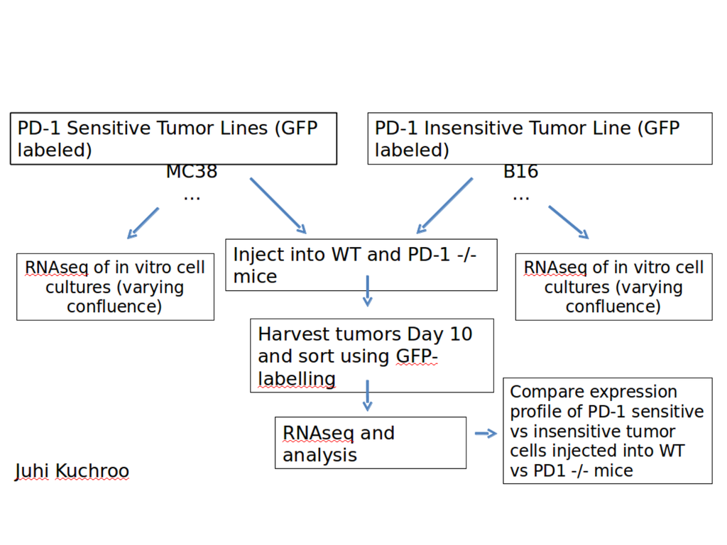

## Workflow:

- run fastq files through [bcbio](https://bcbio-nextgen.readthedocs.org/en/latest/index.html) on Orchestra
- assess QC report link
- simple DEG list for the WT and KO comparison within each cell line

## Setup

### Bioconductor and R libraries used

```r
loadlibs <- function(){
library(ggplot2)
library(reshape)
library(gplots)
library(RColorBrewer)
library(CHBUtils)
library(ggdendro)
library(grid)
library(gridExtra)
library(limma)
library(DESeq2)
library(Biobase)
library(genefilter)
library(splitstackshape)
library(GOstats)
library(edgeR)
library(CHBUtils)
}
suppressPackageStartupMessages(loadlibs())
```

### Set variables

```r
baseDir=getwd()
dataDir=paste(baseDir, "/data", sep="")
resultsDir=paste(baseDir, "/results", sep="")
metaDir=paste(baseDir, "/meta", sep="")

heatcolors.1 <- rev(brewer.pal(6, "YlOrRd"))
heatcolors.2 <- colorRampPalette(brewer.pal(9, "GnBu"))(100)
cbPalette <- cbPalette <- c("#999999", "#E69F00", "#56B4E9", "#009E73", "#F0E442", "#0072B2",
                            "#D55E00", "#CC79A7", "#000000")
```

## RNA-Seq

### Load data

```r
data <- read.delim(file.path(dataDir, 'combined.counts'), header=T, sep="\t", row.names=1, as.is=T)
meta <- read.delim(file.path(metaDir, 'project2.csv'), header=T, sep=",", row.names=1)
meta$sampletype <- factor(paste(meta$celline, "_", meta$genotype, sep=""))
shortname = sapply(row.names(meta), function(x){
                  s <- unlist(strsplit(x, "_"))
                  newname <- paste(s[5], "_", s[6], sep="")}, USE.NAMES=F)
meta$shortname <-shortname

# Reorder data to match meta
ord.names <- sapply(rownames(meta), function(x){
                            s <- strsplit(x, ".", fixed=T)[[1]][1]
                            grep(s, colnames(data))})

data <- data[,as.numeric(ord.names)]
colnames(data) <- row.names(meta)

# Create eset object
eset <- new("ExpressionSet", exprs=as.matrix(data))
pData(eset) <- meta
annot <- read.delim(file.path(dataDir, 'annotated_combined.counts'), sep="\t", header=T, row.names=1)
fData(eset) <- data.frame(symbol=annot$symbol, row.names=row.names(annot), stringsAsFactors = FALSE)
```

### Quality control

From the PCA, samples separate into four distinct group which corresponds to each cell line in vitro and exvivo. The KO and WT do not separate out, but they do tend to cluster together

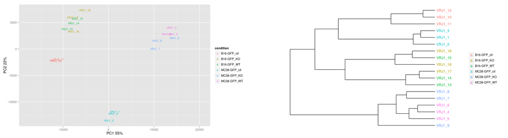

### DESeq2: Finding genes differentially expressed between WT and KO

Starting from count data; create a DESeq object. The design formula (~) is used to estimate the dispersions and to estimate the log2 fold changes of the model. DESeq2 will estimate the library sizes with “estimateSizeFactors”. However, this can only take into account tags that have contributed to your cluster definitions (genes). Imagine that none of your clusters are differentially expressed, but due to some biological or technical artifact, the reads that do not map to clusters are more abundant in one than in the other sample. A normalization based on all counts will skew the clusters in order to account for the non-clusters. Finally, There are three levels of filtering applied in DESeq2.

1. If within a row, all samples have zero counts, the baseMean column will be zero, and the log2 fold change estimates, p-value and adjusted p-value will all be set to NA.
2. If a row contains a sample with an extreme count outlier then the p-value and adjusted p-value are set to NA. These outlier counts are detected by [Cook’s distance](http://en.wikipedia.org/wiki/Cook%27s_distance)
3. If a row is filtered by automatic independent filtering, based on low mean normalized count, then only the adjusted p-value is set to NA.

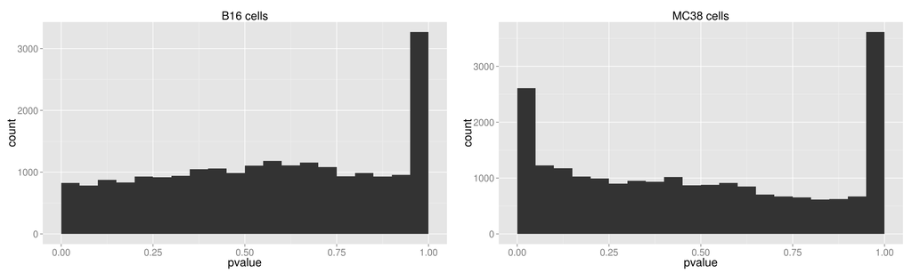

```r
# Create DESeq2 dataset
dds <- DESeqDataSetFromMatrix(countData = exprs(eset), colData = pData(eset), design = ~ sampletype)
dds <- DESeq(dds)

# Matrix of pseudocounts for downstream visualization: two methods
rld <- rlog(dds)

# Extract data of specified contrasts for B16
# resultNames(dds) # uncomment to check names for contrast setup
contrast <- list("sampletypeB16.GFP_KO", "sampletypeB16.GFP_WT")
resB16 <- results(dds, contrast=contrast)

# Extract data of specified contrast for MC38 cells
contrast <- list("sampletypeMC38.GFP_KO", "sampletypeMC38.GFP_WT")
resMC38 <- results(dds, contrast=contrast)


# Plot p-value distributions
df <- data.frame(resB16[4:39017,])
p1 <- ggplot(df, aes(x=pvalue)) + geom_histogram(binwidth=.05) +
      scale_x_continuous(limits=c(0,1)) +
      ggtitle("B16 cells") +
    theme(legend.position = "none",
        plot.title = element_text(size = rel(1.5)),
        axis.title = element_text(size = rel(1.5)),
        axis.text = element_text(size = rel(1.25)))

df <- data.frame(resMC38[4:39017,])
p2 <- ggplot(df, aes(x=pvalue)) + geom_histogram(binwidth=.05) +
      scale_x_continuous(limits=c(0,1)) +
      ggtitle("MC38 cells") +
    theme(legend.position = "none",
        plot.title = element_text(size = rel(1.5)),
        axis.title = element_text(size = rel(1.5)),
        axis.text = element_text(size = rel(1.25)))

grid.arrange(p1, p2, ncol=2)
```

### Significant genes

- Group 1: B16 comparison
- Group 2: MC38 comparison

#### B16

|  | geneSymbol | baseMean | log2FoldChange | lfcSE | stat | pvalue | padj |
| --- | --- | --- | --- | --- | --- | --- | --- |
| ENSMUSG00000028364 | Tnc | 38.212 | -2.460 | 0.4854 | -5.069 | 0 | 0.0057 |
| ENSMUSG00000029661 | Col1a2 | 419.738 | -1.984 | 0.4084 | -4.858 | 0 | 0.0084 |
| ENSMUSG00000037887 | Dusp8 | 77.992 | 1.401 | 0.3297 | 4.247 | 0 | 0.0440 |
| ENSMUSG00000094185 | Gm5445 | 19.228 | 2.615 | 0.5651 | 4.628 | 0 | 0.0131 |
| ENSMUSG00000068246 | Apol9b | 94.020 | -1.747 | 0.3742 | -4.670 | 0 | 0.0131 |
| ENSMUSG00000093514 | Gm9320 | 28.308 | 2.058 | 0.4910 | 4.192 | 0 | 0.0491 |
| ENSMUSG00000024824 | Rad9a | 39.023 | 1.887 | 0.4357 | 4.330 | 0 | 0.0354 |
| ENSMUSG00000090840 | 1700092M07Rik | 9.121 | 3.908 | 0.8901 | 4.391 | 0 | 0.0321 |